# Arend L. Schwab, publications

| **MSc Projects** |  |  |
| --- | --- | --- |

| Delft University of Technology |
| --- |

Down below you will find a collection of possible MSc projects. If you are interested in doing one of these or have some ideas in a project along similar lines please contact me.

**MSc assignment Proposals**

Brake Squeal in Bicycle Disk Brakes

Some brake systems have the annoying habit of making a very high pitched and loud noise while braking, which is called ‘brake squeal’. Such brake squeal is usually caused by friction induced vibration. Some seminal work on brake squeal in bicycle rim brakes has been done by Robin Walhout [1] and Jan Groenhuis [2]. We like to extend that work towards bicycle disk brakes**.**

[figure not shown]

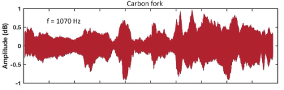

Adaptive speed control  
Modern e-bikes are equipped with a number of sensors which are able to measure: GPS location, forward speed, angular speed and linear acceleration of the rear frame, pedal torque support level, and the ambient temperature, at a sample rate of 2 seconds. These sensors open opportunities within the concept of IoT (Internet of Things) to have vehicle-to-vehicle and vehicle-to-infrastructure communication. This opens a whole set of new applications which can make cycling safer and more time efficient, like: collision prediction, early warning systems, adaptive speed control for green wave, or to enforce speed limits.

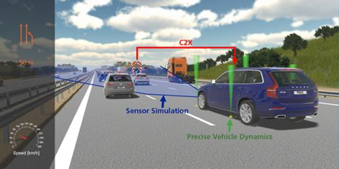

Early warning and crash detection in cycling  
Modern e-bikes have sensors which are able to measure the forward speed, the angular speed and linear acceleration of the rear frame, the pedal torque support level, and the ambient temperature, at a sample rate of 2 seconds. A safety related question is: Can we use this sensor data to detect, at an early stage, the instability of a bicycle and can we detect if the cyclist has crashed?

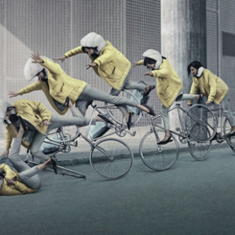

[figure not shown]

Bicycle load cases  
For the structural design of bicycles, it is crucial to have representative load cases. The current tests (HCF and ISO) are historically grown and often do not representative the experienced load cases during daily usage. A more realistic set of load cases could improve the design of bicycles. Modern e-bikes have sensors which are able to measure the forward speed, the angular speed and linear acceleration of the rear frame, the pedal torque support level, and the ambient temperature, at a sample rate of 2 seconds. With the help of IoT technology we would like to explore if these sensors can help to develop the load cases as they are experienced by our fleet. As a parallel step you can also think of a system which with the help of the sensors and the IoT can give information on the actual road quality like potholes and unevenness.

[figure not shown]

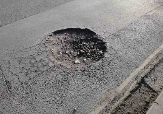

Design Rules for Handling Qualities  
Together with the Royal Gazelle some work has been done to relate bicycle geometry and rider characteristics to handling qualities [1]. Gazelle likes to get more understanding in the effect parameter changes like wheelbase, trail, head angle and mass distribution on the handling qualities of a bicycle. In order to answer questions like: how can we create a better handling for speedpedelecs, or which geometry/layout fits best for a café-racer? Does the mass of the rider or the position of heavy luggage have a large influence on the handling qualities? Can we design for that?

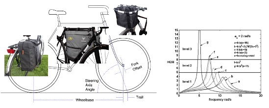

Bicycle Tire Characteristics  
With the novel Wobble tool Royal Gazelle is able to predict possible shimmy behavior for a bicycle from the drawing board. An important and influential parameter in this Wobble tool is the bicycle tire at hand. Unfortunately, little is known about the mechanical characteristics like cornering and camber stiffness of bicycle tires. Tire manufacturers do not report these values for specific tire, often because they are just unknown. For the Royal Gazelle, to make a good choice in which tires to mount on their specific bicycle, there is a need for more insight in these tire characteristics in close connection with the tire manufacturer.

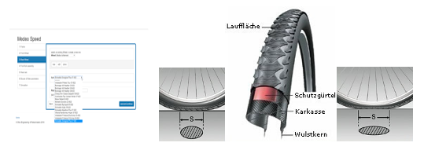

Welke krachten op het voorwiel hebben ernstige balansverstoring tot gevolg bij een fiets?  
Een fiets is een balansvoertuig en bij ongevallen bij fietsen is een verstoring van de balans, gevolgd door een val en bekende toedracht. De oorzaken kunnen divers zijn zoals het met het voorwiel (heel even) raken van een voorganger of het zijdelings raken van een opstaande rand in het wegdek. Er is geen kwantitatief empirisch onderzoek bekend naar de gevoeligheid van de balans van een fiets voor externe krachten die op het voorwiel worden uitgeoefend. Verondersteld wordt dat een kleine verstoring van de stuurinrichting van een fiets door bijvoorbeeld een kleine laterale kracht voor de fietsbalans desastreuze gevolgen heeft.  
Het beoogde onderzoek betreft experimenteel empirisch onderzoek naar verstoringen van de fietsbalans door het gecontroleerd uitoefenen van krachten op het voorwiel van een fiets (zonder berijder).

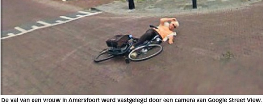

Bicycle Geometry, Dynamics, and Handling;  
why do some bicycles feel different than others?

At the Royal Gazelle bicycle factory there is a vast amount of knowledge about the relation between bicycle geometry and handling. This knowledge is based on experience, and with this experience new bicycles are designed in an evolutionary manner. Academic research on bicycle dynamics and control (handling) has created theoretical knowledge on dynamics and control for bicycles [1,2]. There is a wish to make a connection between the two, by classifying geometry designs as used by Gazelle in a standard manner and relate them to the dynamical behavior as predicted by the recent theoretical bicycle models [2]. This could lead to a revolution in bicycle design.

[figure not shown]

Active stability control for a bicycle

The objective of the proposed MSc assignment is:  
“To develop an optimal control strategy stabilizing the bicycle at low speed”  
Address the following questions:  
- How does the rider perceive this enhanced stability?  
- Can you measure the change (decrease) in control effort from the rider?  
- How does the stability enhancement influence the maneuverability?  
- Is there a trade-off between stability, handling and maneuverability?

[figure not shown]

**Behavior modeling of Vulnerable Road Users**

[figure not shown]

**Modeling shimmy in strollers**

Shimmy is a recurring problem in all of our strollers.  
Mostly by trial and error we are able to keep shimmy under control under normal use, but the lack of a proper underlying theoretical model makes it hard to predict the behavior of new stroller designs, or even to know with which strollers we are near a ‘tipping point’ in dynamic behavior.

[figure not shown]

**Model Order Reduction for coupled ship hydrodynamic and multibody dynamic equations**

A musculoskeletal bicycle rider model

**Bicycle tire testing**

**Simplest Skater Model**

**Haptic steer for a desktop bicycle simulator.**

Bicycle Dynamics and Control

Modelleren van onderwater pijpleiding dynamica tijdens het offshore pijpenleggen

**Simplest Skater Model of the corner**

**Structural impact analysis of a lightweight foldable tail structure**

**Detailed info and finished projects:**

[output not shown]